# Lab 2. Ch. 2 Contingency Tables to Ch. 3 Generalized Linear Models

Discrete Data Analysis and Lab. (326.314)

Author

Junseok Lee

Published

September 19, 2026

## Chapter 2

### Odds Ratio

For a success probability $\pi$, the odds of success are $\pi/(1-\pi)$. For a $2\times2$ table, the odds ratio is

$$OR=\frac{\pi_1/(1-\pi_1)}{\pi_2/(1-\pi_2)}.$$

Independence corresponds to $OR=1$. Reversing the order of either the rows or the columns changes the odds ratio to its reciprocal. Transposing the table does not change its value. These properties make the odds ratio useful for retrospective studies, including case-control studies.

The estimated standard error of the sample log odds ratio is

$$SE\{\log(\widehat{OR})\}
=\sqrt{\frac{1}{n_{11}}+\frac{1}{n_{12}}+\frac{1}{n_{21}}+\frac{1}{n_{22}}}.$$

A Wald confidence interval is constructed on the log scale and then exponentiated.

The `oddsratio()` function can use a $2\times2$ table directly.

```r
library(epitools)

aspirin_table <- matrix(
  c(10933, 104, 10845, 189),
  nrow = 2,
  byrow = TRUE,
  dimnames = list(
    Group = c("Aspirin", "Placebo"),
    Myocardial_infarction = c("No", "Yes")
  )
)

oddsratio(
  aspirin_table,
  method = "wald",
  conf.level = 0.95,
  correction = FALSE
)$measure
```

```
         odds ratio with 95% C.I.
Group     estimate    lower   upper
  Aspirin 1.000000       NA      NA
  Placebo 1.832054 1.440042 2.33078
```

The `orscoreci()` function uses the success count and sample size for each independent binomial sample.

```r
library(PropCIs)

orscoreci(189, 11034, 104, 11037, conf.level = 0.95)
```

```
data:

95 percent confidence interval:
 1.440802 2.329551
```

### Tests of Independence in Two-Way Tables

For an $r\times c$ contingency table, the null hypothesis of independence is

$$H_0:\pi_{ij}=\pi_{i+}\pi_{+j}
\quad\text{for all }i\text{ and }j.$$

Under this hypothesis, the estimated expected frequency in cell $(i,j)$ is

$$\hat\mu_{ij}=\frac{n_{i+}n_{+j}}{n}.$$

Two standard test statistics are the Pearson statistic

$$X^2=\sum_{i=1}^r\sum_{j=1}^c
\frac{(n_{ij}-\hat\mu_{ij})^2}{\hat\mu_{ij}}$$

and the likelihood-ratio statistic

$$G^2=2\sum_{i=1}^r\sum_{j=1}^c
n_{ij}\log\left(\frac{n_{ij}}{\hat\mu_{ij}}\right).$$

For large samples, both statistics have approximately a chi-squared distribution with $(r-1)(c-1)$ degrees of freedom. Large values provide evidence against independence.

A standardized residual for cell $(i,j)$ is

$$\frac{n_{ij}-\hat\mu_{ij}}
{\sqrt{\hat\mu_{ij}(1-\hat\pi_{i+})(1-\hat\pi_{+j})}}.$$

Standardized residuals help identify cells that contribute strongly to a significant test result.

```r
Political <- read.table(
  "https://raw.githubusercontent.com/alanagresti/categorical-data/master/Political.dat",
  header = TRUE
)
Political$party <- factor(Political$party, levels = c("Dem", "Rep", "Ind"))
```

The function `xtabs()` constructs a contingency table from individual observations. The function `margin.table()` obtains marginal totals, and `prop.table()` obtains joint or conditional sample proportions.

```r
gendergap <- xtabs(~ gender + party, data = Political)
gendergap
```

```
        party
gender   Dem Rep Ind
  female 495 272 590
  male   330 265 498
```

```r
margin.table(gendergap, margin = 2)
```

```
party
 Dem  Rep  Ind
 825  537 1088
```

```r
margin.table(gendergap)
```

```
[1] 2450
```

```r
addmargins(gendergap)
```

```
        party
gender    Dem  Rep  Ind  Sum
  female  495  272  590 1357
  male    330  265  498 1093
  Sum     825  537 1088 2450
```

```r
prop.table(gendergap, margin = 1)
```

```
        party
gender         Dem       Rep       Ind
  female 0.3647752 0.2004422 0.4347826
  male   0.3019213 0.2424520 0.4556267
```

```r
prop.table(gendergap)
```

```
        party
gender         Dem       Rep       Ind
  female 0.2020408 0.1110204 0.2408163
  male   0.1346939 0.1081633 0.2032653
```

If the cell counts are already available, the table can be entered as a matrix.

```r
gendergap_counts <- matrix(
  c(495, 272, 590, 330, 265, 498),
  nrow = 2,
  byrow = TRUE,
  dimnames = list(
    Gender = c("Female", "Male"),
    Party = c("Dem", "Rep", "Ind")
  )
)
gendergap_counts
```

```
        Party
Gender   Dem Rep Ind
  Female 495 272 590
  Male   330 265 498
```

```r
chisq.test(gendergap_counts)
```

```
    Pearson's Chi-squared test

data:  gendergap_counts
X-squared = 12.569, df = 2, p-value = 0.001865
```

The test statistics can also be calculated directly.

```r
row_totals <- margin.table(gendergap_counts, margin = 1)
column_totals <- margin.table(gendergap_counts, margin = 2)
total <- margin.table(gendergap_counts)
expected <- outer(row_totals, column_totals) / total

pearson_statistic <- sum((gendergap_counts - expected)^2 / expected)
likelihood_ratio_statistic <- 2 * sum(
  gendergap_counts * log(gendergap_counts / expected)
)

pearson_statistic
```

```
[1] 12.56926
```

```r
likelihood_ratio_statistic
```

```
[1] 12.6009
```

```r
chisq.test(gendergap_counts)$stdres
```

```
        Party
Gender         Dem       Rep       Ind
  Female  3.272365 -2.498557 -1.032199
  Male   -3.272365  2.498557  1.032199
```

### Testing Independence for Ordinal Data

The Pearson and likelihood-ratio tests treat both classifications as nominal and do not use category ordering. When the variables are ordinal, numerical scores can be assigned to the categories. Let $R$ be the sample correlation calculated from those scores. The statistic

$$M^2=(n-1)R^2$$

has approximately a chi-squared distribution with one degree of freedom under independence. This test is sensitive to a linear trend. The scores should reflect meaningful distances between the ordered categories, because the result can depend on their choice.

#### Example: Alcohol Use and Infant Malformation

| Alcohol consumption | Malformation absent | Malformation present | Total |
| --- | --- | --- | --- |
| 0 | 17,066 | 48 | 17,114 |
| $<1$ | 14,464 | 38 | 14,502 |
| 1–2 | 788 | 5 | 793 |
| 3–5 | 126 | 1 | 127 |
| $\ge6$ | 37 | 1 | 38 |

```r
Malform <- matrix(
  c(17066, 48, 14464, 38, 788, 5, 126, 1, 37, 1),
  ncol = 2,
  byrow = TRUE,
  dimnames = list(
    Alcohol = c("0", "<1", "1-2", "3-5", ">=6"),
    Malformation = c("Absent", "Present")
  )
)
Malform
```

```
       Malformation
Alcohol Absent Present
    0    17066      48
    <1   14464      38
    1-2    788       5
    3-5    126       1
    >=6     37       1
```

```r
library(vcdExtra)
CMHtest(
  Malform,
  rscores = c(0, 0.5, 1.5, 4.0, 7.0),
  types = "cor"
)
```

```
Cochran-Mantel-Haenszel Statistics for Alcohol by Malformation

          AltHypothesis  Chisq Df     Prob
cor Nonzero correlation 6.5699  1 0.010372
```

### Exact Inference for Small Samples: Fisher’s Exact Test

For a $2\times2$ table, Fisher’s exact test conditions on the row and column totals. Under independence, one cell count then has a hypergeometric distribution. The test avoids a large-sample chi-squared approximation and is useful when the sample is small or expected frequencies are low.

In Fisher’s tea-tasting experiment, the null and one-sided alternative hypotheses are

$$H_0:\theta=1
\quad\text{versus}\quad
H_a:\theta>1.$$

| Poured first / Guessed first | Tea | Milk |
| --- | --- | --- |
| Tea | 3 | 1 |
| Milk | 1 | 3 |

```r
tea <- matrix(
  c(3, 1, 1, 3),
  nrow = 2,
  byrow = TRUE,
  dimnames = list(
    Poured_first = c("Tea", "Milk"),
    Guessed_first = c("Tea", "Milk")
  )
)

fisher.test(tea)
```

```
    Fisher's Exact Test for Count Data

data:  tea
p-value = 0.4857
alternative hypothesis: true odds ratio is not equal to 1
95 percent confidence interval:
   0.2117329 621.9337505
sample estimates:
odds ratio
  6.408309
```

```r
fisher.test(tea, alternative = "greater")
```

```
    Fisher's Exact Test for Count Data

data:  tea
p-value = 0.2429
alternative hypothesis: true odds ratio is greater than 1
95 percent confidence interval:
 0.3135693       Inf
sample estimates:
odds ratio
  6.408309
```

#### Mid-$P$ Inference

A mid-$P$ test adds half the probability of the observed table to the probability of more extreme tables. It is generally less conservative than the ordinary exact test. The reporting of results should state that a mid-$P$ method was used.

```r
library(epitools)

ormidp.test(3, 1, 1, 3, or = 1)
```

| one.sided | two.sided |
| --- | --- |
| 0.1285714 | 0.2571429 |

The one-sided mid-$P$ value is approximately 0.129.

```r
or.midp(c(3, 1, 1, 3), conf.level = 0.95)$conf.int
```

```
[1]   0.3100508 306.6338538
```

## Chapter 3

### Logistic Regression

Logistic regression is a generalized linear model for a binary response. Its components are

- a binomial random component;
- a linear predictor $\alpha+\sum_{i=1}^p\beta_i x_i$;
- the logit link $\operatorname{logit}(\pi)=\log\{\pi/(1-\pi)\}$.

For a single predictor,

$$\operatorname{logit}\{\pi(x)\}=\alpha+\beta x.$$

The coefficient $\beta$ is the change in the log odds for a one-unit increase in $x$, and $\exp(\beta)$ is the corresponding multiplicative effect on the odds. A probit model instead uses

$$\pi(x)=\Phi(\alpha+\beta x),$$

where $\Phi$ is the standard normal cumulative distribution function.

#### Example: Snoring and Heart Disease

An epidemiological survey of 2,484 subjects investigated the relation between snoring and heart disease. The scores for snoring level are $x=(0,2,4,5)$.

| Snoring | Heart disease: Yes | Heart disease: No |
| --- | --- | --- |
| Never | 24 | 1,355 |
| Occasional | 35 | 603 |
| Nearly every night | 21 | 192 |
| Every night | 30 | 224 |

```r
Heart <- read.table(
  "https://raw.githubusercontent.com/alanagresti/categorical-data/master/Heart.dat",
  header = TRUE
)
Heart$x <- c(0, 2, 4, 5)
Heart$n <- Heart$yes + Heart$no
Heart
```

| snoring | yes | no | x | n |
| --- | --- | --- | --- | --- |
| never | 24 | 1355 | 0 | 1379 |
| occasional | 35 | 603 | 2 | 638 |
| nearly_every_night | 21 | 192 | 4 | 213 |
| every_night | 30 | 224 | 5 | 254 |

The `weights` argument gives the number of binomial trials represented by each sample proportion.

```r
fit_logit <- glm(
  yes / n ~ x,
  family = binomial(link = "logit"),
  weights = n,
  data = Heart
)

summary(fit_logit)
```

```
Call:
glm(formula = yes/n ~ x, family = binomial(link = "logit"), data = Heart,
    weights = n)

Coefficients:
            Estimate Std. Error z value Pr(>|z|)
(Intercept) -3.86625    0.16621 -23.261  < 2e-16 ***
x            0.39734    0.05001   7.945 1.94e-15 ***
---
Signif. codes:  0 '***' 0.001 '**' 0.01 '*' 0.05 '.' 0.1 ' ' 1

(Dispersion parameter for binomial family taken to be 1)

    Null deviance: 65.9045  on 3  degrees of freedom
Residual deviance:  2.8089  on 2  degrees of freedom
AIC: 27.061

Number of Fisher Scoring iterations: 4
```

```r
fitted(fit_logit)
```

```
         1          2          3          4
0.02050742 0.04429511 0.09305411 0.13243885
```

```r
coef(fit_logit)
```

```
(Intercept)           x
 -3.8662481   0.3973366
```

The fitted model is

$$\operatorname{logit}\{\hat\pi(x)\}=-3.866+0.397x,$$

or

$$\hat\pi(x)=\frac{\exp(-3.866+0.397x)}{1+\exp(-3.866+0.397x)}.$$

A linear probability model uses the identity link,

$$\pi(x)=\alpha+\beta x.$$

```r
fit_linear <- glm(
  yes / n ~ x,
  family = quasi(link = "identity", variance = "mu(1-mu)"),
  weights = n,
  data = Heart
)

summary(fit_linear, dispersion = 1)
```

```
Call:
glm(formula = yes/n ~ x, family = quasi(link = "identity", variance = "mu(1-mu)"),
    data = Heart, weights = n)

Coefficients:
            Estimate Std. Error z value Pr(>|z|)
(Intercept) 0.017247   0.003451   4.998 5.80e-07 ***
x           0.019778   0.002805   7.051 1.77e-12 ***
---
Signif. codes:  0 '***' 0.001 '**' 0.01 '*' 0.05 '.' 0.1 ' ' 1

(Dispersion parameter for quasi family taken to be 1)

    Null deviance: 65.904481  on 3  degrees of freedom
Residual deviance:  0.069191  on 2  degrees of freedom
AIC: NA

Number of Fisher Scoring iterations: 3
```

```r
fitted(fit_linear)
```

```
         1          2          3          4
0.01724668 0.05680231 0.09635793 0.11613574
```

The fitted linear probability model is approximately

$$\hat\pi(x)=0.017+0.020x.$$

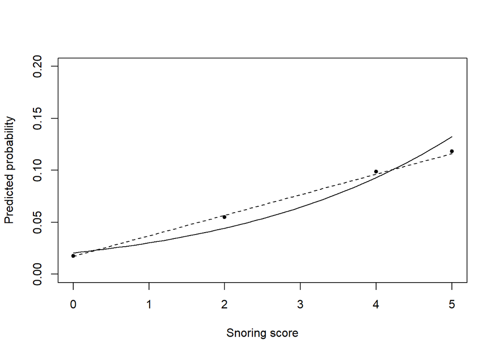

```r
newdata <- data.frame(x = seq(0, 5, by = 0.1))
logistic_fit <- predict(fit_logit, newdata, type = "response")
linear_fit <- predict(fit_linear, newdata, type = "response")

plot(
  newdata$x, logistic_fit,
  type = "l",
  xlab = "Snoring score",
  ylab = "Predicted probability",
  ylim = c(0, 0.2)
)
lines(newdata$x, linear_fit, lty = 2)
points(Heart$x, Heart$yes / Heart$n, pch = 20)
```

### Poisson Regression

Poisson regression is a generalized linear model for a count response. With a log link,

$$\log\{\mu(x)\}=\alpha+\beta x.$$

A one-unit increase in $x$ multiplies the mean by $\exp(\beta)$. The Poisson distribution assumes $\operatorname{Var}(Y)=E(Y)$. If the data show greater variability, standard errors from an ordinary Poisson model can be too small.

#### Example: Female Horseshoe Crabs and Their Satellites

The response is the number of satellite males near a female crab. Available explanatory variables include shell color, spine condition, weight, and carapace width.

```r
Crabs <- read.table(
  "https://raw.githubusercontent.com/alanagresti/categorical-data/master/Crabs.dat",
  header = TRUE
)
Crabs
```

| crab | sat | y | weight | width | color | spine |
| --- | --- | --- | --- | --- | --- | --- |
| 1 | 8 | 1 | 3.050 | 28.3 | 2 | 3 |
| 2 | 0 | 0 | 1.550 | 22.5 | 3 | 3 |
| 3 | 9 | 1 | 2.300 | 26.0 | 1 | 1 |
| 4 | 0 | 0 | 2.100 | 24.8 | 3 | 3 |
| 5 | 4 | 1 | 2.600 | 26.0 | 3 | 3 |
| 6 | 0 | 0 | 2.100 | 23.8 | 2 | 3 |
| 7 | 0 | 0 | 2.350 | 26.5 | 1 | 1 |
| 8 | 0 | 0 | 1.900 | 24.7 | 3 | 2 |
| 9 | 0 | 0 | 1.950 | 23.7 | 2 | 1 |
| 10 | 0 | 0 | 2.150 | 25.6 | 3 | 3 |

[output cut: 163 more lines]

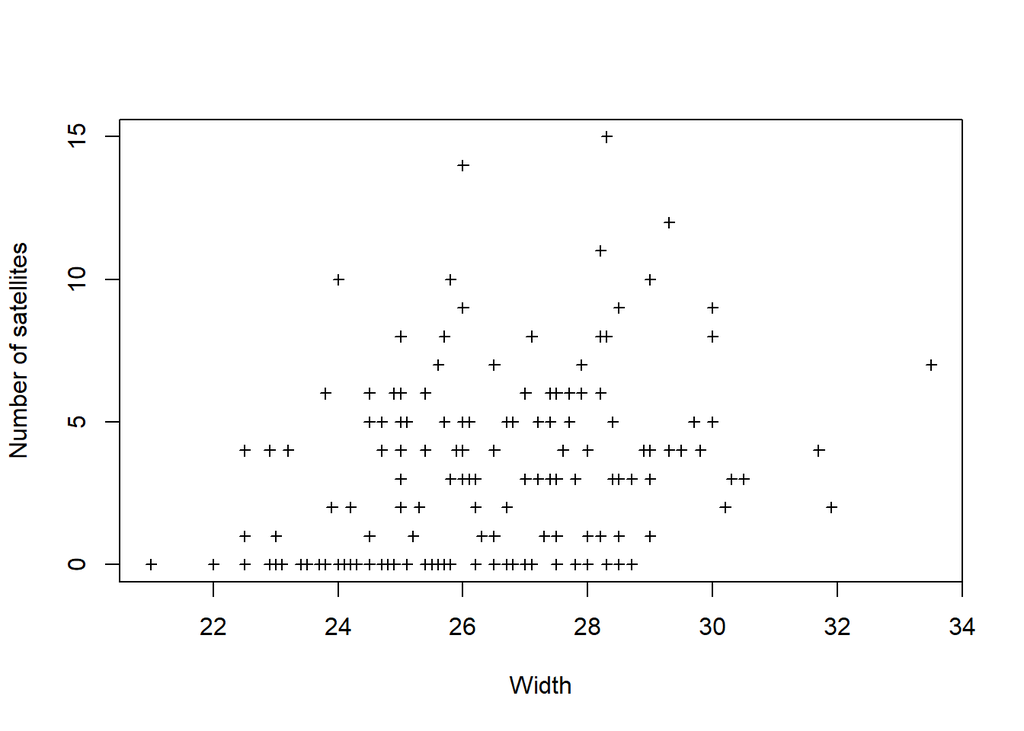

```r
plot(
  sat ~ width,
  data = Crabs,
  pch = 3,
  cex = 0.7,
  xlab = "Width",
  ylab = "Number of satellites"
)
```

```r
fit_poisson <- glm(
  sat ~ width,
  family = poisson(link = "log"),
  data = Crabs
)
summary(fit_poisson)
```

```
Call:
glm(formula = sat ~ width, family = poisson(link = "log"), data = Crabs)

Coefficients:
            Estimate Std. Error z value Pr(>|z|)
(Intercept) -3.30476    0.54224  -6.095  1.1e-09 ***
width        0.16405    0.01997   8.216  < 2e-16 ***
---
Signif. codes:  0 '***' 0.001 '**' 0.01 '*' 0.05 '.' 0.1 ' ' 1

(Dispersion parameter for poisson family taken to be 1)

    Null deviance: 632.79  on 172  degrees of freedom
Residual deviance: 567.88  on 171  degrees of freedom
AIC: 927.18

Number of Fisher Scoring iterations: 6
```

The fitted model is

$$\log\{\hat\mu(x)\}=-3.305+0.164x.$$

Thus, a 1 cm increase in width multiplies the estimated mean number of satellites by $\exp(0.164)=1.178$, an increase of about 17.8%.

### Statistical Inference and Model Checking

The Wald test uses the estimate and its estimated standard error at the unrestricted maximum likelihood estimate. The score test evaluates the likelihood under the null hypothesis. The likelihood-ratio test compares maximized likelihoods under the null and alternative models. For small samples or sparse data, Wald inference can be the least reliable of the three.

#### Example: Political Ideology and Belief in Evolution

The survey item is: *“Human beings, as we know them today, developed from earlier species of animals. True or false?”*

The response is opinion about evolution, and the explanatory variable is political ideology, scored from 1 for extremely conservative to 7 for extremely liberal.

```r
Evo <- read.table(
  "https://raw.githubusercontent.com/alanagresti/categorical-data/master/Evolution.dat",
  header = TRUE
)
Evo$n <- Evo$true + Evo$false
Evo
```

| ideology | true | false | n |
| --- | --- | --- | --- |
| 1 | 11 | 37 | 48 |
| 2 | 46 | 104 | 150 |
| 3 | 70 | 72 | 142 |
| 4 | 241 | 214 | 455 |
| 5 | 78 | 36 | 114 |
| 6 | 89 | 24 | 113 |
| 7 | 36 | 6 | 42 |

The model and hypothesis are

$$\operatorname{logit}\{\pi(x)\}=\alpha+\beta x,
\qquad
H_0:\beta=0\quad\text{versus}\quad H_a:\beta\ne0.$$

#### Wald Test

```r
fit_evolution <- glm(
  true / n ~ ideology,
  family = binomial(link = "logit"),
  weights = n,
  data = Evo
)

summary(fit_evolution)
```

```
Call:
glm(formula = true/n ~ ideology, family = binomial(link = "logit"),
    data = Evo, weights = n)

Coefficients:
            Estimate Std. Error z value Pr(>|z|)
(Intercept) -1.75658    0.20500  -8.569   <2e-16 ***
ideology     0.49422    0.05092   9.706   <2e-16 ***
---
Signif. codes:  0 '***' 0.001 '**' 0.01 '*' 0.05 '.' 0.1 ' ' 1

(Dispersion parameter for binomial family taken to be 1)

    Null deviance: 113.20  on 6  degrees of freedom
Residual deviance:   3.72  on 5  degrees of freedom
AIC: 42.332

Number of Fisher Scoring iterations: 3
```

```r
confint(fit_evolution)
```

```
                2.5 %     97.5 %
(Intercept) -2.165294 -1.3609733
ideology     0.396166  0.5959414
```

The fitted model is

$$\operatorname{logit}\{\hat\pi(x)\}=-1.757+0.494x.$$

The estimated ideology effect is approximately 0.494 with a standard error of 0.051. The corresponding Wald statistic gives very strong evidence of an ideology effect.

#### Likelihood-Ratio Test

```r
car::Anova(fit_evolution, test.statistic = "LR")
```

|  | LR Chisq | Df | Pr(>Chisq) |
| --- | --- | --- | --- |
| ideology | 109.4828 | 1 | 1.272045e-25 |

The likelihood-ratio statistic is approximately 109.48 with one degree of freedom.

#### Score Test

The score test is fitted under the null model and evaluates the contribution of the omitted predictor.

```r
fit_evolution_null <- glm(
  true / n ~ 1,
  family = binomial(link = "logit"),
  weights = n,
  data = Evo
)

statmod::glm.scoretest(fit_evolution_null, Evo$ideology)^2
```

```
[1] 104.101
```

The score chi-squared statistic is approximately 104.10 with one degree of freedom.

#### Standardized Pearson Residuals

A standardized residual compares an observed response with its fitted value after accounting for its estimated variability. Values larger than about 2 or 3 in absolute value deserve attention, but patterns across observations are more informative than an isolated cutoff.

```r
evolution_results <- data.frame(
  ideology = Evo$ideology,
  true = Evo$true,
  false = Evo$false,
  n = Evo$n,
  sample_proportion = Evo$true / Evo$n,
  fitted = fitted(fit_evolution),
  standardized_residual = rstandard(fit_evolution, type = "pearson")
)
evolution_results
```

|  | ideology | true | false | n | sample_proportion | fitted | standardized_residual |
| --- | --- | --- | --- | --- | --- | --- | --- |
| 1 | 1 | 11 | 37 | 48 | 0.2291667 | 0.2205679 | 0.1611162 |
| 2 | 2 | 46 | 104 | 150 | 0.3066667 | 0.3168813 | -0.3515386 |
| 3 | 3 | 70 | 72 | 142 | 0.4929577 | 0.4319445 | 1.6480176 |
| 4 | 4 | 241 | 214 | 455 | 0.5296703 | 0.5548525 | -1.4995488 |
| 5 | 5 | 78 | 36 | 114 | 0.6842105 | 0.6713982 | 0.3248519 |
| 6 | 6 | 89 | 24 | 113 | 0.7876106 | 0.7700750 | 0.5413625 |
| 7 | 7 | 36 | 6 | 42 | 0.8571429 | 0.8459201 | 0.2206605 |

No standardized Pearson residual exceeds 2 in absolute value, so no single ideology group shows an obvious large discrepancy from the fitted model.